# environmental_data_preperation

# AMO data

Downloaded from [NOAA](https://www.esrl.noaa.gov/psd/data/timeseries/AMO/) (AMO, unsmoothed, short) as a txt and then converted to a .csv

load raw data

```r
amoraw <- read.csv("../data/env/amon.us.data.csv", header = FALSE)
head(amoraw)
```

ok first col = year, the others represent the month. Give the columns some proper names

```r
colnames(amoraw) <- c("year","Jan", "Feb", "Mar", "Apr", "May", "Jun", "Jul", "Aug", "Sep", "Oct", "Nov", "Dec")
head(amoraw)
```

The data downloaded from the site indidcated that NA values are represented by -99.99. Lets replace those values with NA

```r
amoraw <- replace(amoraw,amoraw==-99.99, NA)
```

Now subset the dataset to start in 1996 (the capelin data starts in 1998, but you want some previous time period stuff)

```r
amoraw <- amoraw[amoraw$year >= 1996, ]
head(amoraw)
```

And just for fun, plot the AMO… follow the tutorial [here](http://www.stat.pitt.edu/stoffer/tsa4/R_toot.htm)

```r
amocolumn <- matrix(t(amoraw[ ,2:13]), ncol=1) #month data is in col 2 - 13
amocolumn1 <- as.vector(amocolumn)
amotimeseries <- ts(amocolumn1, frequency = 12, start = c(1996,1))
plot.ts(amotimeseries)
abline(h = 0)
dev.copy(png, "../output/env/amo.png") #this prints a png of the plot
dev.off() #this turns off the print command
```

First I will create a matrix that takes all of the raw data and then appends some extra columns - year average value, year phase (warm or cold) and then seasonal values (spring, summer, autum, winter) + seasonal phase (warm cold)

Spring: 1 March - 31 May (col 4:6) Summer: 1 June - 31 August (col 7:9) Autumn: 1 Sept - 31 Nov (col 10:12) Winter: 1 Dec - 28 Feb (col 13 from prev year, 1:2)

```r
amophases <- amoraw
amophases$YearAvg <- rowMeans(amophases[2:13], na.rm = TRUE) #the month data is in col 2-13
amophases$SpringAvg <-  rowMeans(amophases[4:6], na.rm = TRUE)
amophases$SummerAvg <-  rowMeans(amophases[7:9], na.rm = TRUE)
amophases$AutumnAvg <-  rowMeans(amophases[10:12], na.rm = TRUE)
```

winter has a different format - the columns are in 1 & 2, & 13 from the previous column, which means the rowmeans function needs a bit of tweaking…

1. shift the dec column you created down by 1

```r
library(useful)
amophases <- shift.column(data = amophases, columns = "Dec", len = 1, up = FALSE)
amophases
write.csv(amophases, file = "../output/env/amo.csv", row.names = FALSE) #for some reason you need to write to a csv and then reload for the next step to work properly...
```

the shifted data is in Dec.Shifted…

```r
amophases <- read.csv("../output/env/amo.csv")
amophases$WinterAvg <- rowMeans(amophases[, c("Dec.Shifted", "Jan", "Feb")], na.rm = TRUE)
amophases
```

Now label the phases positive, negative (or avg if any happen to be at 0)

```r
amophases$YearPhase[amophases$YearAvg ==0] <- "avg"
amophases$YearPhase[amophases$YearAvg >0] <- "positive"
amophases$YearPhase[amophases$YearAvg <0] <- "negative"
amophases$SpringPhase[amophases$SpringAvg ==0] <- "avg"
amophases$SpringPhase[amophases$SpringAvg >0] <- "positive"
amophases$SpringPhase[amophases$SpringAvg <0] <- "negative"
amophases$SummerPhase[amophases$SummerAvg ==0] <- "avg"
amophases$SummerPhase[amophases$SummerAvg >0] <- "positive"
amophases$SummerPhase[amophases$SummerAvg <0] <- "negative"
amophases$AutumnPhase[amophases$AutumnAvg ==0] <- "avg"
amophases$AutumnPhase[amophases$AutumnAvg >0] <- "positive"
amophases$AutumnPhase[amophases$AutumnAvg <0] <- "negative"
amophases$WinterPhase[amophases$WinterAvg ==0] <- "avg"
amophases$WinterPhase[amophases$WinterAvg >0] <- "positive"
amophases$WinterPhase[amophases$WinterAvg <0] <- "negative"
```

now save this as a new csv

```r
write.csv(amophases, file = "../output/env/amo.csv", row.names = FALSE)
```

# NAO

```r
naoraw <- read.csv("../data/env/amon.us.data.csv", header = FALSE)
head(naoraw)
```

lets give some column names. col 1 year, 2:13 are the months

```r
colnames(naoraw) <- c("year","1", "2", "3", "4", "5", "6", "7", "8", "9", "10", "11", "12")
head(naoraw)
```

NA values are represented by -99.99. Change these to NA

```r
naoraw <- replace(naoraw,naoraw==-99.99, NA)
```

Now subset the dataset to start in 1996 (the capelin data starts in 1998, but you want some previous time period stuff)

```r
nao <- naoraw[naoraw$year >= 1996, ]
head(nao)
```

```r
naocolumn <- matrix(t(amoraw[ ,2:13]), ncol=1) #month data is in col 2 - 13
naocolumn1 <- as.vector(naocolumn)
naotimeseries <- ts(naocolumn1, frequency = 12, start = c(1996,1))
plot.ts(naotimeseries)
abline(h = 0)
dev.copy(png, "../output/env/nao.png") #this prints a png of the plot
dev.off() #this turns off the print command
```

First I will create a matrix that takes all of the raw data and then appends some extra columns - year average value, year phase (warm or cold) and then seasonal values (spring, summer, autum, winter) + seasonal phase (warm cold)

Spring: 1 March - 31 May (col 4:6) Summer: 1 June - 31 August (col 7:9) Autumn: 1 Sept - 31 Nov (col 10:12) Winter: 1 Dec - 28 Feb (col 13 from prev year, 1:2)

```r
naophases <- nao
naophases$YearAvg <- rowMeans(naophases[2:13], na.rm = TRUE) #the month data is in col 2-13
naophases$SpringAvg <- rowMeans(naophases[4:6], na.rm = TRUE)
naophases$SummerAvg <- rowMeans(naophases[7:9], na.rm = TRUE)
naophases$AutumnAvg <- rowMeans(naophases[10:12], na.rm = TRUE)
```

winter has a different format - the columns are in 1 & 2, & 13 from the previous column, which means the rowmeans function needs a bit of tweaking…

shift the dec column you created down by 1

```r
library(useful)
naophases <- shift.column(data = naophases, columns = "12", len = 1, up = FALSE)
naophases
write.csv(naophases, file = "../output/env/nao.csv", row.names = FALSE) #for some reason you need to write to a csv and then reload for the next step to work properly...
```

he shifted data is in 12.Shifted…

```r
naophases <- read.csv("../output/env/nao.csv")
naophases$WinterAvg <- rowMeans(naophases[ , c("X12.Shifted", "X1", "X2")], na.rm = TRUE)  #x because apparently all the col names start with x for some reason...
naophases
```

Now label the phases positive, negative (or avg if any happen to be at 0)

```r
naophases$YearPhase[naophases$YearAvg ==0] <- "avg"
naophases$YearPhase[naophases$YearAvg >0] <- "positive"
naophases$YearPhase[naophases$YearAvg <0] <- "negative"
naophases$SpringPhase[naophases$SpringAvg ==0] <- "avg"
naophases$SpringPhase[naophases$SpringAvg >0] <- "positive"
naophases$SpringPhase[naophases$SpringAvg <0] <- "negative"
naophases$SummerPhase[naophases$SummerAvg ==0] <- "avg"
naophases$SummerPhase[naophases$SummerAvg >0] <- "positive"
naophases$SummerPhase[naophases$SummerAvg <0] <- "negative"
naophases$AutumnPhase[naophases$AutumnAvg ==0] <- "avg"
naophases$AutumnPhase[naophases$AutumnAvg >0] <- "positive"
naophases$AutumnPhase[naophases$AutumnAvg <0] <- "negative"
naophases$WinterPhase[naophases$WinterAvg ==0] <- "avg"
naophases$WinterPhase[naophases$WinterAvg >0] <- "positive"
naophases$WinterPhase[naophases$WinterAvg <0] <- "negative"
```

now save this as a new csv

```r
write.csv(naophases, file = "../output/env/nao.csv", row.names = FALSE)
```

# Bathymetric

bottom depth from GEBCO

```r
library(ncdf4)
library(marmap)
bat <-readGEBCO.bathy("../data/env/GEBCO_2014_2D_-70.0_34.0_-43.0_70.0.nc")
summary(bat)
```

```
Bathymetric data of class 'bathy', with 3241 rows and 4322 columns
Latitudinal range: 34 to 70 (34 N to 70 N)
Longitudinal range: -70 to -43 (70 W to 43 W)
Cell size: 0.5 minute(s)

Depth statistics:
```

```
   Min. 1st Qu.  Median    Mean 3rd Qu.    Max.
  -5994   -3704    -418   -1633      56    2796
```

```
First 5 columns and rows of the bathymetric matrix:
```

```
                  33.9958333333333 34.0041666666667 34.0125 34.0208333333333 34.0291666666667
-69.9958333333333            -5368            -5367   -5366            -5365            -5365
-69.9875                     -5368            -5367   -5368            -5367            -5367
-69.9791666666667            -5369            -5370   -5370            -5370            -5370
-69.9708333333333            -5368            -5367   -5370            -5372            -5374
-69.9625                     -5366            -5366   -5368            -5376            -5384
```

create pretty custom color palette and then plot the bathy laye

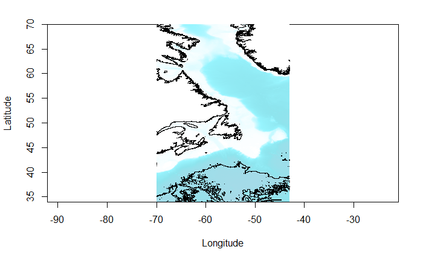

```r
blues <- colorRampPalette(c("lightblue", "cadetblue2", "cadetblue1", "white"))
plot(bat, n = 1, image = TRUE, bpal = blues(100))
```

lovely jubbely

add the species data…

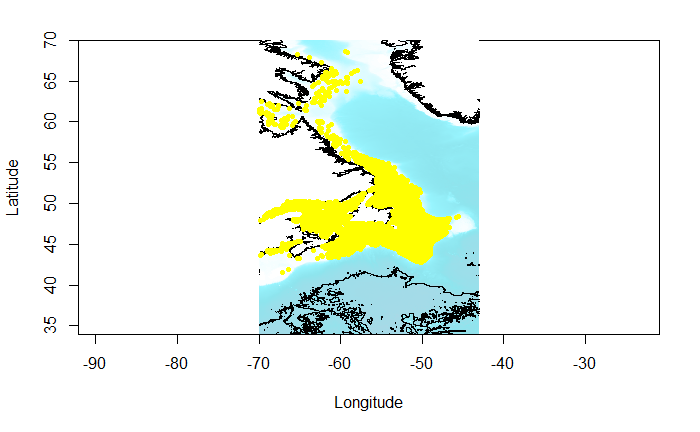

```r
data_aea <-read.csv( "../output/bio/data_aea_cell_amo_nao_bins_env.csv", header = TRUE) #just for canada pc as not loaded
plot(bat, n = 1, image = TRUE, bpal = blues(100))
points(data_aea$decimalLongitude, data_aea$decimalLatitude, pch = 20, col = "yellow") #note these are both the wgs84 images
```

and now get depth… note all the points and bathy data is wgs!

```r
data_aea$bottom_depth <- get.depth(bat, data_aea[ ,5:4], locator = FALSE)
data_aea$bottom_depth <- data_aea$bottom_depth[, 3] #this step is because get.bath actually produces it's own dataframe with long, lat, and depth. This is extracting the depth column and deplacing data_aea$bottom_depth with the correct data.
head(data_aea)
```

|  | year | month | id | decimalLatitude | decimalLongitude | datecollected | institutioncode | individualcount | depth | resname | originalscientificname | collectioncode | day | occurrence | nafo_zone | gear | cell_id | decimalLongitude.1 | decimalLatitude.1 | amo_sample | amo_prev | amo_winter | nao_sample | nao_prev | nao_winter | depth_layer | depthlayerno | mlp | salinty_1 | … |
| --- | --- | --- | --- | --- | --- | --- | --- | --- | --- | --- | --- | --- | --- | --- | --- | --- | --- | --- | --- | --- | --- | --- | --- | --- | --- | --- | --- | --- | --- | --- |
| 1 | 1998 | 10 | 386669852 | 53.95 | -54.91 | 1998-10-26 12:00:00+01 | DFONL | xx | 172 | DFO Newfoundland and Labrador Region Ecosystem Trawl Surveys | Mallotus villosus | BT_standard_sets | 26 | 1 | 2J | bottom_trawl_campelen_1800 | 2849 | 331170.37 | 1549820.7 | 0.382 | 0.412 | -0.094 | 0.382 | 0.15 | -0.094 | 180.54993 | 30 | NA | NA | … |
| 2 | 1998 | 10 | 386669881 | 53.63 | -55.51 | 1998-10-27 12:00:00+01 | DFONL | xx | 140 | DFO Newfoundland and Labrador Region Ecosystem Trawl Surveys | Mallotus villosus | BT_standard_sets | 27 | 1 | 2J | bottom_trawl_campelen_1800 | 2883 | 294592.13 | 1511221.3 | 0.382 | 0.412 | -0.094 | 0.382 | 0.15 | -0.094 | 147.40625 | 28 | NA | NA | … |
| 3 | 1998 | 10 | 386669904 | 53.72 | -55.73 | 1998-10-27 12:00:00+01 | DFONL | xx | 126 | DFO Newfoundland and Labrador Region Ecosystem Trawl Surveys | Mallotus villosus | BT_standard_sets | 27 | 1 | 2J | bottom_trawl_campelen_1800 | 2882 | 279536.56 | 1520353.1 | 0.382 | 0.412 | -0.094 | 0.382 | 0.15 | -0.094 | 120.00000 | 26 | NA | NA | … |
| 4 | 1998 | 10 | 386411062 | 45.19 | -52.85 | 1998-10-10 12:00:00+02 | DFONL | xx | 93 | DFO Newfoundland and Labrador Region Ecosystem Trawl Surveys | Mallotus villosus | BT_standard_sets | 10 | 1 | 3O | bottom_trawl_campelen_1800 | 4863 | 568120.66 | 594666.9 | 0.382 | 0.412 | -0.094 | 0.382 | 0.15 | -0.094 | 97.04131 | 24 | NA | NA | … |
| 5 | 1998 | 10 | 386669825 | 54.15 | -54.81 | 1998-10-26 12:00:00+01 | DFONL | xx | 175 | DFO Newfoundland and Labrador Region Ecosystem Trawl Surveys | Mallotus villosus | BT_standard_sets | 26 | 1 | 2J | bottom_trawl_campelen_1800 | 2811 | 335931.39 | 1572697.5 | 0.382 | 0.412 | -0.094 | 0.382 | 0.15 | -0.094 | 180.54993 | 30 | NA | NA | … |
| 6 | 1998 | 10 | 386667763 | 56.04 | -59.43 | 1998-10-13 12:00:00+02 | DFONL | xx | 522 | DFO Newfoundland and Labrador Region Ecosystem Trawl Surveys | Mallotus villosus | BT_standard_sets | 13 | 1 | 2H | bottom_trawl_campelen_1800 | 2460 | 35127.37 | 1772366.2 | 0.382 | 0.412 | -0.094 | 0.382 | 0.15 | -0.094 | 508.63989 | 40 | NA | NA | … |

```r
write.csv(data_aea,"../output/bio/data_aea_cell_amo_nao_bins_btmdepth.csv", row.names = FALSE)
```

And now create a raster of Gebco in aea for mapping once the SDM is done…

```r
library(raster)
gebco <- raster("../data/env/GEBCO_2014_2D_-70.0_34.0_-43.0_70.0.nc")
gebco
gebco_aea <- projectRaster(gebco, aea)
gebco_aea
```

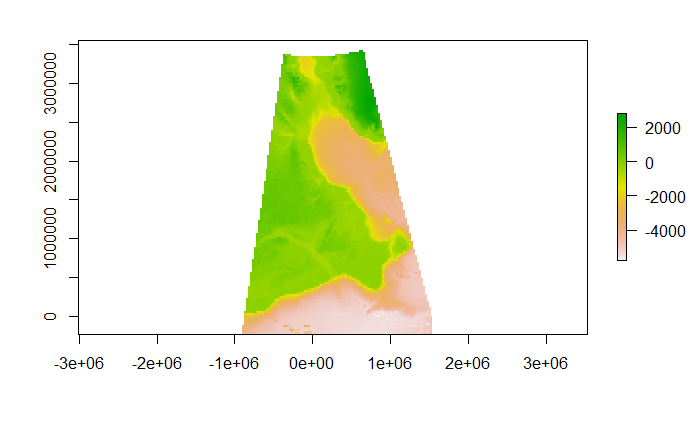

```r
plot(gebco_aea)
```

# attach environmental correlates

This loop runs through the netcdf files and then looks for which rows in data_aea it should extract the value to point from, and at what depth (netcDF layer)

First you need to put the observations (data_aea) into a spatialpointsdataframe.

```r
xy2 <- data_aea[ ,c(18,19)] # This is to tell R where the coordinates are (in column 18 and 19). Note that the column order needs to be longitude, latitude
data_aea_sp <- SpatialPointsDataFrame(coords = xy2, data = data_aea, proj4string = CRS("+proj=aea +lat_1=50 +lat_2=70 +lat_0=40 +lon_0=-60 +x_0=0 +y_0=0 +ellps=GRS80 +datum=NAD83 +units=m +no_defs")) # The CRS is used here is for the albers equal area projection.
```

[output not shown]

and the loop. Note that MLP and SSH only have a single layer and as such they do not have a statement to extract at depth.

```r
netcdf_list <- list.files("../data/env/netcdf", pattern = '*.nc', full.names = TRUE) #true means the full path is included
no_netcdf <- length(netcdf_list) #for the loop - need to know how many files to cycle through
netcdf_name <- list.files("../data/env/netcdf", pattern = '*.nc', full.names = FALSE) #false means the path is not included
library (ncdf4)
for (i in 1:no_netcdf){
  print(netcdf_name[i]) #this just prints the name of the netCDF R is working one
  brkyr <- as.integer(sapply(strsplit(netcdf_name[i], "_"), "[[", 1)) # extracting the first part of the netcdf filename (which is the year)
  brkmth <- as.integer(sapply(strsplit(netcdf_name[i], "_"), "[[", 2)) # extracting the second part of the netcdf filename (which is the month)
  brkvar <- (sapply(strsplit(netcdf_name[i], "_"), "[[", 3)) # extracting the third part of the netcdf (inc.nc)
  temp_brick <- brick(netcdf_list[i], lvar = 4)
  temp_brick <- projectRaster(temp_brick, aea)
    for (j in 1:nrow(data_aea_sp)) {
      print (j)
      de <- data_aea_sp$depthlayerno[[j]]  # a variable for the observation depth layer
      yr <- (data_aea_sp$year[j])  # a variable for the observation year
      mth <- (data_aea_sp$month[j])  # a variable for the observation month
          if (brkyr == yr & brkmth == mth & brkvar == "temp.nc"){

             data_aea_sp$temp_surface[j] <- extract(x=temp_brick[[1]], y = data_aea_sp[j, ])
              if (is.na(de)){
                data_aea_sp$temp_depth[j] <- NA
              } else
                data_aea_sp$temp_depth[j] <- extract(x=temp_brick[[de]], y = data_aea_sp[j, ])
          } else if (brkyr == yr & brkmth == mth & brkvar == "salinity.nc") {
              data_aea_sp$salinity_surface[j] <- extract(x=temp_brick[[1]], y = data_aea_sp[j, ])
              if (is.na(de)){
                data_aea_sp$salinity_depth[j] <- NA
              } else
                data_aea_sp$salinity_depth[j] <- extract(x=temp_brick[[de]], y = data_aea_sp[j, ])
          } else if (brkyr == yr & brkmth == mth & brkvar == "chl.nc") {
              data_aea_sp$chl_surface[j] <- extract(x=temp_brick[[1]], y = data_aea_sp[j, ])
              if (is.na(de)){
                data_aea_sp$chl_depth[j] <- NA
              } else
                data_aea_sp$chl_depth[j] <- extract(x=temp_brick[[de]], y = data_aea_sp[j, ])
          } else if (brkyr == yr & brkmth == mth & brkvar == "o2.nc") {
              data_aea_sp$o2_surface[j] <- extract(x=temp_brick[[1]], y = data_aea_sp[j, ])
              if (is.na(de)){
                data_aea_sp$o2_depth[j] <- NA
              } else
                data_aea_sp$o2_depth[j] <- extract(x=temp_brick[[de]], y = data_aea_sp[j, ])
          } else if (brkyr == yr & brkmth == mth & brkvar == "mlp.nc") {
              data_aea_sp$mlp_surface[j] <- extract(x=temp_brick[[1]], y = data_aea_sp[j, ])
          } else if (brkyr == yr & brkmth == mth & brkvar == "ssh.nc") {
              data_aea_sp$ssh_surface[j] <- extract(x=temp_brick[[1]], y = data_aea_sp[j, ])

          }
    }
  }
}
```